# invariance analysis

Assesses robustness of RSA model fits to particular choice of procedures.

- Model structure (glms)
  - tdi vs tdci
- Model fit method
  - rank betas versus linear betas (spearman’s versus pearson’s) | categorical models
  - rank betas versus linear coefficients (spearman’s versus mean contrast) | categorical models
  - rank betas versus tau-a | all models

```r
library(here)
library(magrittr)
library(dplyr)
library(data.table)
```

```r
library(ggplot2)
library(mikeutils)
source(here("code", "_strings.R"))
source(here("code", "_funs.R"))
source(here("code", "_get_atlas.R"))

stats.subjs <- rbind(
  fread(here("out", "rsa", "stats", paste0("subjs_pro_bias_acc-only_mmp_pearson_residual_glm-tdic.csv"))),
  fread(here("out", "rsa", "stats", paste0("subjs_pro_bias_acc-only_mmp_pearson_residual_glm-tdi.csv"))),
  fread(here("out", "rsa", "stats", paste0("subjs_pro_bias_acc-only_mmp_pearson_residual_glm-tdclust.csv")))
  )
stats.subjs <- stats.subjs[is.analysis.group == TRUE]  ## EXCLUDE HELD OUT SUBJECTS!

stats.subjs.taua <- fread(
  here("out", "rsa", "stats", paste0("subjs_pro_bias_acc-only_mmp_pearson_residual_taua.csv"))
  )[is.analysis.group == TRUE]  ## EXCLUDE HELD OUT SUBJECTS!
```

# model structure: **tdi** versus **tdic** (rank betas)

The **tdi** model
$$\textbf{y} \sim
\textbf{x}_{\text{targt}}\beta_{\text{targt}} +
\textbf{x}_{\text{distr}}\beta_{\text{distr}} +
\textbf{x}_{\text{incon}}\beta_{\text{incon}}$$
and the **tdci** model
$$\textbf{y} \sim
\textbf{x}_{\text{targt}}\beta_{\text{targt}} +
\textbf{x}_{\text{distr}}\beta_{\text{distr}} +
\textbf{x}_{\text{incon}}\beta_{\text{incon}} +
\textbf{x}_{\text{congr}}\beta_{\text{congr}}$$
differ in the inclusion of the congruency regressor ($\textbf{x}_{\text{congr}}$). The congruency regressor is an indicator for correlations between congruent items. Thus, the intercept (‘baseline’) of these models differs in whether congruent items are included (in **tdi**) or excluded (**tdic**).

The coefficients (betas) of interest from these models ($\beta_{\text{targt}}$, $\beta_{\text{distr}}$, $\beta_{\text{incon}}$) reflect the (semi-partial spearman) correlation with the regressor, relative to the intercept. These alternative parameterizations may therefore give differing results.

## stats

```r
d <- stats.subjs[model %in% c("tdi", "tdic") & param == "incongruency" & y == "rank"]

tdi.vs.tdic <- d %>%
  group_by(model, param, roi.hemi) %>%
  summarize(
    v    = wilcox.test(beta, alternative = "greater")$statistic,
    p    = wilcox.test(beta, alternative = "greater")$p.value,
    beta = tanh(mean(atanh(beta))),  ## must be last in this summarize()
  ) %>%
  group_by(model, param) %>%
  mutate(p.fdr = p.adjust(p, method = "fdr"), p.holm = p.adjust(p, method = "holm"))
```

## results

ROIs identified by both **tdi** and **tdic**.

```r
intersect(
  filter(tdi.vs.tdic, p.fdr < 0.05, model == "tdic")$roi.hemi,
  filter(tdi.vs.tdic, p.fdr < 0.05, model == "tdi")$roi.hemi
)
```

```
##  [1] "6ma_l"  "6ma_r"  "8BM_r"  "IP0_r"  "IP1_l"  "LIPd_l" "LO2_r"  "MIP_l"
##  [9] "RSC_l"  "s6-8_r"
```

ROIs in **tdi** but not in **tdic**. (i.e., should be ROIs in which congruent patterns tended to be dissimilar).

```r
setdiff(
  filter(tdi.vs.tdic, p.fdr < 0.05, model == "tdi")$roi.hemi,
  filter(tdi.vs.tdic, p.fdr < 0.05, model == "tdic")$roi.hemi
)
```

```
## character(0)
```

ROIs in tdic but not in tdi. (should be ROIs in which congruent patterns tended to be similar).

```r
setdiff(
  filter(tdi.vs.tdic, p.fdr < 0.05, model == "tdic")$roi.hemi,
  filter(tdi.vs.tdic, p.fdr < 0.05, model == "tdi")$roi.hemi
)
```

```
## [1] "9-46d_l" "p32pr_r"
```

ROIs where tdic and tdi incongruency betas are significantly different.

```r
tdi.vs.tdic.wide <- d %>%
  select(subj, roi.hemi, model, beta) %>%
  group_by(model, roi.hemi) %>%
  tidyr::spread(model, beta)

tdi.vs.tdic.wide %>%
  filter(roi.hemi %in% tdi.vs.tdic$roi.hemi[tdi.vs.tdic$p.fdr < 0.05]) %>%
  summarize(
    v    = wilcox.test(tdic, tdi, paired = TRUE)$statistic,
    p    = wilcox.test(tdic, tdi, paired = TRUE)$p.value,
    beta = tanh(mean(atanh(tdic) - atanh(tdi))),  ## must be last in this summarize()
  ) %>%
  mutate(p.fdr = p.adjust(p, method = "fdr"), p.holm = p.adjust(p, method = "holm")) %>%
  filter(p.fdr < 0.05)  ## no ROIs
```

```
## # A tibble: 1 x 6
##   roi.hemi     v        p    beta   p.fdr  p.holm
##   <chr>    <dbl>    <dbl>   <dbl>   <dbl>   <dbl>
## 1 RSC_l      243 0.000139 -0.0130 0.00167 0.00167
```

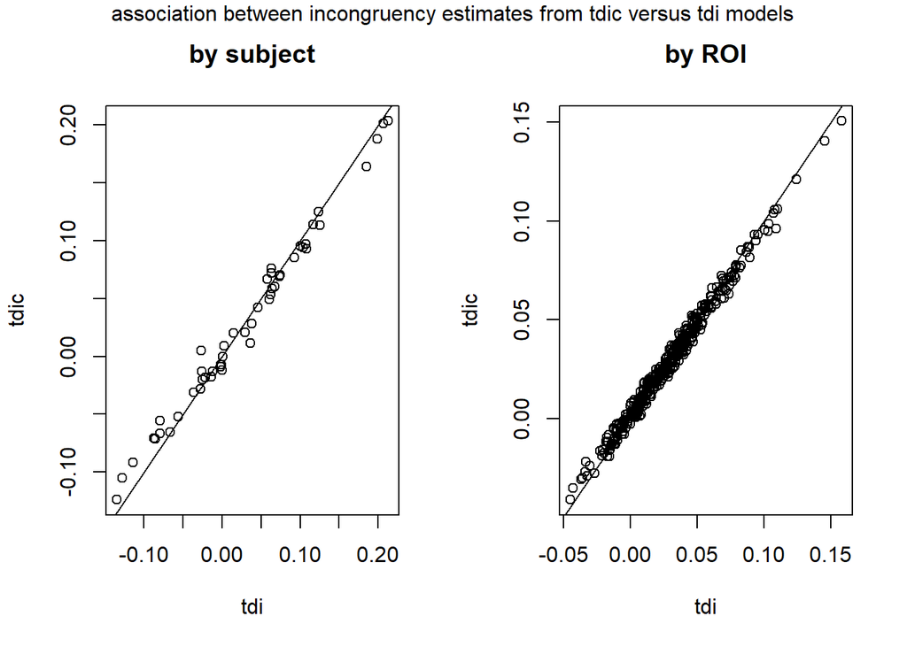

```r
## plot

plot.new()

par(mfrow = c(1, 2))

tdi.vs.tdic.wide %>%
  group_by(subj) %>%
  summarize_if(is.numeric, function(x) tanh(mean(atanh(x)))) %>%
  select(tdi, tdic) %>%
  plot
abline(0, 1)
title("by subject")

tdi.vs.tdic.wide %>%
  group_by(roi.hemi) %>%
  summarize_if(is.numeric, function(x) tanh(mean(atanh(x)))) %>%
  select(tdi, tdic) %>%
  plot
abline(0, 1)
title("by ROI")

mtext("association between incongruency estimates from tdic versus tdi models", side = 3, line = -1, outer = TRUE)
```

```r
## correlations:

tdi.vs.tdic.wide %>%
  group_by(roi.hemi) %>%
  summarize_if(is.numeric, function(x) tanh(mean(atanh(x)))) %>%
  select(tdi, tdic) %>%
  cor
```

```
##            tdi      tdic
## tdi  1.0000000 0.9938826
## tdic 0.9938826 1.0000000
```

```r
tdi.vs.tdic.wide %>%
  group_by(subj) %>%
  summarize_if(is.numeric, function(x) tanh(mean(atanh(x)))) %>%
  select(tdi, tdic) %>%
  cor
```

```
##            tdi      tdic
## tdi  1.0000000 0.9935666
## tdic 0.9935666 1.0000000
```

## conclusion

No notable differences between **tdic** and **tdi** models. Use **tdic** as main categorical model structure as it estimates additional information (congruency), and has a more intuitive baseline (intercept). (But report both).

# model fit method: betas from rank regression versus from linear regression

Regression models were either fit on repsonse variables that were rank transformed, or on the raw values. The vector **r** is composed of each unique element of the observed representational simialrity matrix (for a give ROI and subject).

The rank model is then specified by
$$rank(\textbf{r}) \sim
\textbf{x}_{\text{targt}}\beta_{\text{targt}} +
\textbf{x}_{\text{distr}}\beta_{\text{distr}} +
\textbf{x}_{\text{incon}}\beta_{\text{incon}} +
\textbf{x}_{\text{congr}}\beta_{\text{congr}}$$
where $rank$ indicates the rank transform. Similarly, the linear model is specified by
$$atanh(\textbf{r}) \sim
\textbf{x}_{\text{targt}}\beta_{\text{targt}} +
\textbf{x}_{\text{distr}}\beta_{\text{distr}} +
\textbf{x}_{\text{incon}}\beta_{\text{incon}} +
\textbf{x}_{\text{congr}}\beta_{\text{congr}}$$
where $atanh$ indicates the Fisher’s z-transform.

The rank-transformed regression betas are eqivalent to a semi-partial spearman’s correlation between model RSM and observed. The linear regression betas are eqivalent to a semi-partial pearson’s correlation.

Here I assess whether these transformations may lead to different interpretation of the results.

```r
d.tdic <- stats.subjs[model == "tdic"]

stats.group.tdic <- d.tdic %>%
  group_by(param, y, roi.hemi) %>%
  summarize(
    v    = wilcox.test(beta, alternative = "greater")$statistic,
    p    = wilcox.test(beta, alternative = "greater")$p.value,
    beta = tanh(mean(atanh(beta))),  ## must be last in this summarize()
  ) %>%
  group_by(param, y) %>%
  mutate(p.fdr = p.adjust(p, method = "fdr"), p.holm = p.adjust(p, method = "holm"))
```

## results

ROIs identified by both **rank** and **linear**.

```r
params <- c("target", "distractor", "incongruency")

rank.vs.line.intersect <- lapply(
  params, function(x) {
    intersect(
      filter(stats.group.tdic, p.fdr < 0.05, param == x, y == "rank")$roi.hemi,
      filter(stats.group.tdic, p.fdr < 0.05, param == x, y == "z")$roi.hemi
      )
  }
)
rank.vs.line.intersect <- setNames(rank.vs.line.intersect, params)

rank.vs.line.intersect
```

```
## $target
##   [1] "1_l"      "1_r"      "10d_l"    "10pp_l"   "10r_r"    "10v_l"
##   [7] "10v_r"    "11l_l"    "11l_r"    "2_l"      "23c_l"    "23c_r"
##  [13] "24dd_l"   "24dd_r"   "24dv_r"   "31pv_r"   "3a_l"     "3a_r"
##  [19] "3b_l"     "3b_r"     "4_l"      "4_r"      "43_l"     "43_r"
##  [25] "44_l"     "44_r"     "45_l"     "46_l"     "47l_l"    "47m_r"
##  [31] "47s_l"    "55b_l"    "55b_r"    "5m_l"     "5mv_l"    "5mv_r"
##  [37] "6a_r"     "6d_l"     "6d_r"     "6ma_r"    "6mp_l"    "6mp_r"
##  [43] "6r_l"     "6r_r"     "6v_l"     "6v_r"     "7AL_r"    "7PC_l"
##  [49] "7PC_r"    "8Ad_l"    "8Ad_r"    "8Av_l"    "8Av_r"    "8BM_l"
##  [55] "8BM_r"    "8C_l"     "8C_r"     "9-46d_r"  "9m_r"     "9p_l"
##  [61] "a10p_l"   "a10p_r"   "a24_l"    "a24_r"    "a24pr_r"  "a32pr_r"
##  [67] "A4_l"     "A4_r"     "a47r_l"   "a47r_r"   "A5_l"     "A5_r"
##  [73] "a9-46v_r" "AAIC_r"   "AIP_l"    "AIP_r"    "AVI_l"    "AVI_r"
##  [79] "d32_l"    "d32_r"    "DVT_l"    "DVT_r"    "FEF_l"    "FEF_r"
```

[output cut: 26 more lines]

ROIs in **rank** but not in **linear**.

```r
rank.vs.line.notinlinear <- lapply(
  params, function(x) {
    setdiff(
      filter(stats.group.tdic, p.fdr < 0.05, param == x, y == "rank")$roi.hemi,
      filter(stats.group.tdic, p.fdr < 0.05, param == x, y == "z")$roi.hemi
      )
  }
)
rank.vs.line.notinlinear <- setNames(rank.vs.line.notinlinear, params)

rank.vs.line.notinlinear
```

```
## $target
##  [1] "24dv_l"  "7PL_r"   "8BL_r"   "9a_l"    "9a_r"    "a24pr_l" "IP0_l"
##  [8] "PCV_r"   "STSvp_r" "TE1m_l"  "TPOJ1_r" "V6A_l"   "V8_r"
##
## $distractor
## character(0)
##
## $incongruency
## character(0)
```

ROIs in **linear** but not in **rank**.

```r
rank.vs.line.notinrank <- lapply(
  params, function(x) {
    setdiff(
      filter(stats.group.tdic, p.fdr < 0.05, param == x, y == "z")$roi.hemi,
      filter(stats.group.tdic, p.fdr < 0.05, param == x, y == "rank")$roi.hemi
      )
  }
)
rank.vs.line.notinrank <- setNames(rank.vs.line.notinrank, params)

rank.vs.line.notinrank
```

```
## $target
##  [1] "10pp_r"  "13l_r"   "2_r"     "23d_l"   "7Am_l"   "A1_l"    "i6-8_r"
##  [8] "IFSa_r"  "Ig_r"    "LIPd_l"  "LIPd_r"  "MBelt_l" "MIP_r"   "p24_r"
## [15] "p32_l"   "PFt_l"   "RI_r"    "STSdp_l" "TE1p_l"  "V3B_r"   "VMV3_l"
##
## $distractor
## [1] "V3_r"
##
## $incongruency
## [1] "IFJa_l" "IPS1_l" "SCEF_l" "SFL_l"
```

ROIs where **rank** and **linear** model betas are significantly different.

```r
rank.vs.line.wide <- d.tdic %>%
  filter(param %in% params) %>%
  select(subj, roi.hemi, param, y, beta) %>%
  group_by(param, y, roi.hemi) %>%
  tidyr::spread(y, beta)

rank.vs.line.diff <- rank.vs.line.wide %>%
  group_by(roi.hemi, param) %>%
  summarize(
    v    = wilcox.test(z, rank, paired = TRUE)$statistic,
    p    = wilcox.test(z, rank, paired = TRUE)$p.value,
    beta = tanh(mean(atanh(z) - atanh(rank))),  ## must be last in this summarize()
  ) %>%
  filter(p < 0.05)

## target

rank.vs.line.diff %>%
  filter(
    param == "target", roi.hemi %in% c(
      ## union of sets:
      rank.vs.line.intersect$target,
      rank.vs.line.notinlinear$target,
      rank.vs.line.notinrank$target
      )
    ) %>%
  arrange(beta)
```

```
## # A tibble: 24 x 5
## # Groups:   roi.hemi [24]
##    roi.hemi param      v       p     beta
##    <chr>    <chr>  <dbl>   <dbl>    <dbl>
##  1 PBelt_r  target   408 0.0417  -0.00801
##  2 a24pr_l  target   379 0.0195  -0.00721
##  3 V6A_l    target   343 0.00667 -0.00721
##  4 23c_l    target   393 0.0285  -0.00661
##  5 PSL_r    target   413 0.0471  -0.00657
##  6 PHT_l    target   404 0.0378  -0.00643
##  7 a9-46v_r target   397 0.0316  -0.00631
##  8 PEF_r    target   847 0.0190   0.00480
##  9 A5_l     target   811 0.0483   0.00485
## 10 FOP5_r   target   821 0.0378   0.00501
## # ... with 14 more rows
```

```r
## distractor

rank.vs.line.diff %>%
  filter(
    param == "distractor", roi.hemi %in% c(
      ## union of sets:
      rank.vs.line.intersect$distractor,
      rank.vs.line.notinlinear$distractor,
      rank.vs.line.notinrank$distractor
      )
    ) %>%
  arrange(beta)
```

```
## # A tibble: 0 x 5
## # Groups:   roi.hemi [0]
## # ... with 5 variables: roi.hemi <chr>, param <chr>, v <dbl>, p <dbl>,
## #   beta <dbl>
```

```r
## incongruency

rank.vs.line.diff %>%
  filter(
    param == "incongruency", roi.hemi %in% c(
      ## union of sets:
      rank.vs.line.intersect$incongruency,
      rank.vs.line.notinlinear$incongruency,
      rank.vs.line.notinrank$incongruency
      )
    ) %>%
  arrange(beta)
```

```
## # A tibble: 1 x 5
## # Groups:   roi.hemi [1]
##   roi.hemi param            v      p    beta
##   <chr>    <chr>        <dbl>  <dbl>   <dbl>
## 1 IFJa_l   incongruency   846 0.0195 0.00893
```

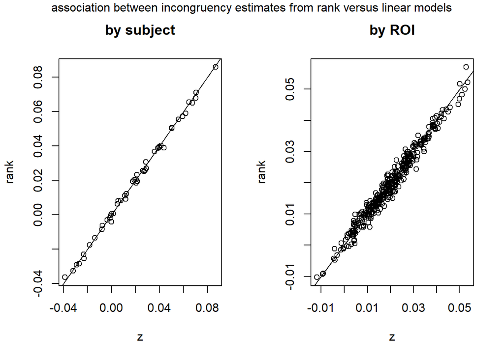

```r
## plot

plot.new()

par(mfrow = c(1, 2))

rank.vs.line.wide %>%
  group_by(subj) %>%
  summarize_if(is.numeric, function(x) tanh(mean(atanh(x)))) %>%
  select(z, rank) %>%
  plot
abline(0, 1)
title("by subject")

rank.vs.line.wide %>%
  group_by(roi.hemi) %>%
  summarize_if(is.numeric, function(x) tanh(mean(atanh(x)))) %>%
  select(z, rank) %>%
  plot
abline(0, 1)
title("by ROI")

mtext("association between incongruency estimates from rank versus linear models", side = 3, line = -1, outer = TRUE)
```

```r
## correlations:

rank.vs.line.wide %>%
  group_by(subj) %>%
  summarize_if(is.numeric, function(x) tanh(mean(atanh(x)))) %>%
  select(z, rank) %>%
  cor
```

```
##              z      rank
## z    1.0000000 0.9986173
## rank 0.9986173 1.0000000
```

```r
rank.vs.line.wide %>%
  group_by(roi.hemi) %>%
  summarize_if(is.numeric, function(x) tanh(mean(atanh(x)))) %>%
  select(z, rank) %>%
  cor
```

```
##              z      rank
## z    1.0000000 0.9858125
## rank 0.9858125 1.0000000
```

## conclusions

There seems to be some loss of sensitivity in using a rank-transformed response variable. Specifically, the linear model identifies a handful of target and incongruency coding ROIs that the rank model did not. (Most of these ROIs are coding for target.) Some of these ROIs have significantly greater betas from linear versus rank, but again most of these are for the target regressor. Further the effect sizes of the difference are quite small.

This loss of sensitivity is expected with rank procedures. But because it is the default for RSA model fitting, and it does not seem to be massively obscuring many positive results, it is preferrable.

# model fit method: betas from rank regression versus bivariate correlations from kendall’s $\tau_A$

## stats

#### **task coding analysis**: test each regressor against zero (baseline)

```r
d.tdic.rank <- d.tdic[y == "rank"]

stats.group.taua <- stats.subjs.taua %>%
  filter(param %in% params) %>%
  group_by(param, roi.hemi) %>%
  summarize(
    v    = wilcox.test(taua, alternative = "greater")$statistic,
    p    = wilcox.test(taua, alternative = "greater")$p.value,
    taua = tanh(mean(atanh(taua))),  ## must be last in this summarize()
  ) %>%
  group_by(param) %>%
  mutate(p.fdr = p.adjust(p, method = "fdr"), p.holm = p.adjust(p, method = "holm"))
```

[output not shown]

[output not shown]

[output not shown]

[output not shown]

[output cut: 25 more lines]

[output not shown]

[output not shown]

[output not shown]

[output not shown]

[output cut: 22 more lines]

[output not shown]

[output not shown]

[output cut: 28 more lines]

[output not shown]

[output not shown]

[output not shown]

[output not shown]

[output not shown]

[output cut: 46 more lines]

[output not shown]

[output not shown]

[output not shown]

[output not shown]

[output not shown]

[output not shown]

[output not shown]

[output cut: 76 more lines]

[output not shown]

[output not shown]

[output cut: 94 more lines]

[output not shown]

[output not shown]

[output not shown]

[output not shown]

[output not shown]

[output cut: 16 more lines]

[output not shown]

[output not shown]

[output cut: 37 more lines]

[output not shown]

[output not shown]

[output not shown]

[output not shown]

[output not shown]

[output not shown]

[output not shown]

[output not shown]

[output not shown]

[output not shown]

[output not shown]

[output not shown]

[output not shown]

[output cut: 25 more lines]

[output not shown]

[output not shown]

[output not shown]

[output not shown]

[output cut: 22 more lines]

[output not shown]

[output not shown]

[output cut: 28 more lines]

[output not shown]

[output not shown]

[output not shown]

[output not shown]

[output not shown]

[output cut: 46 more lines]

[output not shown]

[output not shown]

[output not shown]

[output not shown]

[output not shown]

[output not shown]

[output not shown]

[output cut: 76 more lines]

[output not shown]

[output not shown]

[output cut: 94 more lines]

[output not shown]

[output not shown]

[output not shown]

[output not shown]

[output not shown]

[output cut: 16 more lines]

[output not shown]

[output not shown]

[output cut: 37 more lines]

[output not shown]

[output not shown]

[output not shown]

[output not shown]

[output not shown]

[output not shown]

[output not shown]

[output not shown]

[output not shown]

#### **preference analysis**: pairwise comparisons

```r
stats.pairs.tdic <- d.tdic.rank %>%
  filter(param %in% params) %>%
  group_by(roi.hemi) %>%
  summarize(
    out = list(
      pairwise.wilcox.test(beta, param, paired = TRUE, alternative = "two.sided", p.adjust.method = "fdr")
    )
  )
pvals <- vapply(stats.pairs.tdic$out, function(.) .$p.value[lower.tri(diag(2), diag = TRUE)], numeric(3))
pvals <- t(pvals)
colnames(pvals) <- c("p.incon.distr", "p.targt.distr", "p.targt.incon")
stats.pairs.tdic <- as.data.frame(cbind(roi.hemi = stats.pairs.tdic$roi.hemi, pvals), stringsAsFactors = FALSE)

## get mean diffs

stats.pairs.tdic %<>% full_join(
  d.tdic.rank %>%
    filter(param %in% params) %>%
    group_by(roi.hemi) %>%
    summarize(
      b.incon.distr = tanh(mean(atanh(beta[param == "incongruency"]) - atanh(beta[param == "distractor"]))),
      b.targt.distr = tanh(mean(atanh(beta[param == "target"]) - atanh(beta[param == "distractor"]))),
      b.targt.incon = tanh(mean(atanh(beta[param == "target"]) - atanh(beta[param == "incongruency"]))),
    ),
  by = "roi.hemi"
)

# stats.pairs.tdic %<>% full_join(mmp, by = "roi.hemi") %>% as.data.table
```

```r
stats.pairs.taua <- stats.subjs.taua %>%
  filter(param %in% params) %>%
  group_by(roi.hemi) %>%
  summarize(
    out = list(
      pairwise.wilcox.test(taua, param, paired = TRUE, alternative = "two.sided", p.adjust.method = "fdr")
    )
  )
```

[output not shown]

[output not shown]

[output not shown]

[output not shown]

[output not shown]

[output not shown]

```r
pvals <- vapply(stats.pairs.taua$out, function(.) .$p.value[lower.tri(diag(2), diag = TRUE)], numeric(3))
pvals <- t(pvals)
colnames(pvals) <- c("p.incon.distr", "p.targt.distr", "p.targt.incon")
stats.pairs.taua <- as.data.frame(cbind(roi.hemi = stats.pairs.taua$roi.hemi, pvals), stringsAsFactors = FALSE)

## get mean diffs

stats.pairs.taua %<>% full_join(
  stats.subjs.taua %>%
    filter(param %in% params) %>%
    group_by(roi.hemi) %>%
    summarize(
      b.incon.distr = tanh(mean(atanh(taua[param == "incongruency"]) - atanh(taua[param == "distractor"]))),
      b.targt.distr = tanh(mean(atanh(taua[param == "target"]) - atanh(taua[param == "distractor"]))),
      b.targt.incon = tanh(mean(atanh(taua[param == "target"]) - atanh(taua[param == "incongruency"]))),
    ),
  by = "roi.hemi"
)

# stats.pairs.tdic %<>% full_join(mmp, by = "roi.hemi") %>% as.data.table
```

## results

#### **task coding analysis**: test each regressor against zero (baseline)

ROIs identified by both **rank** and **$\tau_A$**.

```r
rank.vs.taua.intersect <- lapply(
  params, function(x) {
    intersect(
      filter(stats.group.tdic, p.fdr < 0.05, param == x, y == "rank")$roi.hemi,
      filter(stats.group.tdic, p.fdr < 0.05, param == x)$roi.hemi
      )
  }
)
rank.vs.taua.intersect <- setNames(rank.vs.taua.intersect, params)

rank.vs.taua.intersect
```

```
## $target
##   [1] "1_l"      "1_r"      "10d_l"    "10pp_l"   "10r_r"    "10v_l"
##   [7] "10v_r"    "11l_l"    "11l_r"    "2_l"      "23c_l"    "23c_r"
##  [13] "24dd_l"   "24dd_r"   "24dv_l"   "24dv_r"   "31pv_r"   "3a_l"
##  [19] "3a_r"     "3b_l"     "3b_r"     "4_l"      "4_r"      "43_l"
##  [25] "43_r"     "44_l"     "44_r"     "45_l"     "46_l"     "47l_l"
##  [31] "47m_r"    "47s_l"    "55b_l"    "55b_r"    "5m_l"     "5mv_l"
##  [37] "5mv_r"    "6a_r"     "6d_l"     "6d_r"     "6ma_r"    "6mp_l"
##  [43] "6mp_r"    "6r_l"     "6r_r"     "6v_l"     "6v_r"     "7AL_r"
##  [49] "7PC_l"    "7PC_r"    "7PL_r"    "8Ad_l"    "8Ad_r"    "8Av_l"
##  [55] "8Av_r"    "8BL_r"    "8BM_l"    "8BM_r"    "8C_l"     "8C_r"
##  [61] "9-46d_r"  "9a_l"     "9a_r"     "9m_r"     "9p_l"     "a10p_l"
##  [67] "a10p_r"   "a24_l"    "a24_r"    "a24pr_l"  "a24pr_r"  "a32pr_r"
##  [73] "A4_l"     "A4_r"     "a47r_l"   "a47r_r"   "A5_l"     "A5_r"
##  [79] "a9-46v_r" "AAIC_r"   "AIP_l"    "AIP_r"    "AVI_l"    "AVI_r"
```

[output cut: 28 more lines]

ROIs in **rank** but not in **$\tau_A$**.

```r
rank.vs.taua.notintaua <- lapply(
  params, function(x) {
    setdiff(
      filter(stats.group.tdic, p.fdr < 0.05, param == x, y == "rank")$roi.hemi,
      filter(stats.group.tdic, p.fdr < 0.05, param == x)$roi.hemi
      )
  }
)
rank.vs.taua.notintaua <- setNames(rank.vs.taua.notintaua, params)

rank.vs.taua.notintaua
```

```
## $target
## character(0)
##
## $distractor
## character(0)
##
## $incongruency
## character(0)
```

ROIs in **$\tau_A$** but not in **rank**.

```r
rank.vs.taua.notinrank <- lapply(
  params, function(x) {
    setdiff(
      filter(stats.group.tdic, p.fdr < 0.05, param == x)$roi.hemi,
      filter(stats.group.tdic, p.fdr < 0.05, param == x, y == "rank")$roi.hemi
      )
  }
)
rank.vs.taua.notinrank <- setNames(rank.vs.taua.notinrank, params)

rank.vs.taua.notinrank
```

```
## $target
##  [1] "10pp_r"  "13l_r"   "2_r"     "23d_l"   "7Am_l"   "A1_l"    "i6-8_r"
##  [8] "IFSa_r"  "Ig_r"    "LIPd_l"  "LIPd_r"  "MBelt_l" "MIP_r"   "p24_r"
## [15] "p32_l"   "PFt_l"   "RI_r"    "STSdp_l" "TE1p_l"  "V3B_r"   "VMV3_l"
##
## $distractor
## [1] "V3_r"
##
## $incongruency
## [1] "IFJa_l" "IPS1_l" "SCEF_l" "SFL_l"
```

##### Direct comparison.

ROIs where **rank** and **$\tau_A$** model betas are significantly different.

```r
d.tdic.taua <- stats.subjs.taua %>%
  filter(param %in% c("incongruency", "target", "distractor", "congruency")) %>%
  full_join(d.tdic.rank %>% select(subj, roi.hemi, param, beta))
rank.vs.taua.diff <- d.tdic.taua %>%
  group_by(roi.hemi, param) %>%
  summarize(
    v    = wilcox.test(beta, taua, paired = TRUE)$statistic,
    p    = wilcox.test(beta, taua, paired = TRUE)$p.value,
    diff = tanh(mean(atanh(beta) - atanh(taua))),  ## must be last in this summarize()
  ) %>%
  filter(p < 0.05) %>%
  as.data.frame

## target

rank.vs.taua.diff %>%
  filter(
    param == "target", roi.hemi %in% c(
      ## union of sets:
      rank.vs.taua.intersect$target,
      rank.vs.taua.notintaua$target,
      rank.vs.taua.notinrank$target
      )
    ) %>%
  arrange(diff)
```

```
##     roi.hemi  param    v            p       diff
## 1       TF_r target  819 3.968945e-02 0.01081134
## 2        H_r target  832 2.847658e-02 0.01135703
## 3     AAIC_r target  822 3.682013e-02 0.01142772
## 4      FFC_r target  818 4.068629e-02 0.01165154
## 5     VMV3_l target  813 4.598766e-02 0.01196820
## 6      OFC_l target  829 3.079285e-02 0.01197065
## 7      OP1_r target  843 2.120118e-02 0.01200070
## 8     LIPd_l target  835 2.630921e-02 0.01248100
## 9        1_l target  824 3.500517e-02 0.01267310
## 10    LIPv_l target  840 2.300754e-02 0.01280447
## 11      A4_l target  813 4.598766e-02 0.01286707
## 12    PFcm_r target  848 1.845951e-02 0.01288516
## 13      A5_l target  814 4.488404e-02 0.01291734
## 14      MT_r target  830 3.000375e-02 0.01305402
```

[output cut: 182 more lines]

```r
## distractor

rank.vs.taua.diff %>%
  filter(
    param == "distractor", roi.hemi %in% c(
      ## union of sets:
      rank.vs.taua.intersect$distractor,
      rank.vs.taua.notintaua$distractor,
      rank.vs.taua.notinrank$distractor
      )
    ) %>%
  arrange(diff)
```

```
##   roi.hemi      param    v            p       diff
## 1     V3_r distractor  941 8.101371e-04 0.01850605
## 2     V1_l distractor 1025 1.601561e-05 0.03006738
## 3     V2_l distractor 1059 2.198967e-06 0.03136011
```

```r
## incongruency

rank.vs.taua.diff %>%
  filter(
    param == "incongruency", roi.hemi %in% c(
      ## union of sets:
      rank.vs.taua.intersect$incongruency,
      rank.vs.taua.notintaua$incongruency,
      rank.vs.taua.notinrank$incongruency
      )
    ) %>%
  arrange(diff)
```

```
##    roi.hemi        param   v            p       diff
## 1     SFL_l incongruency 857 1.428609e-02 0.02761961
## 2   9-46d_l incongruency 967 2.734639e-04 0.03038516
## 3    IFJa_l incongruency 882 6.674315e-03 0.03168546
## 4     6ma_r incongruency 928 1.342641e-03 0.03286427
## 5     RSC_l incongruency 888 5.498562e-03 0.03604487
## 6   p32pr_r incongruency 921 1.745034e-03 0.03641370
## 7    s6-8_r incongruency 993 8.271798e-05 0.03702366
## 8     LO2_r incongruency 895 4.361282e-03 0.03762155
## 9     6ma_l incongruency 921 1.745034e-03 0.03999128
## 10   IPS1_l incongruency 894 4.509767e-03 0.04103447
## 11    8BM_r incongruency 912 2.420454e-03 0.04336195
## 12   SCEF_l incongruency 895 4.361282e-03 0.04626830
## 13    IP0_r incongruency 928 1.342641e-03 0.04756380
## 14   LIPd_l incongruency 988 1.050535e-04 0.05331323
## 15    MIP_l incongruency 965 2.984073e-04 0.06331310
## 16    IP1_l incongruency 954 4.768491e-04 0.06550160
```

All differences are positive (i.e., greater betas than $\tau_A$).

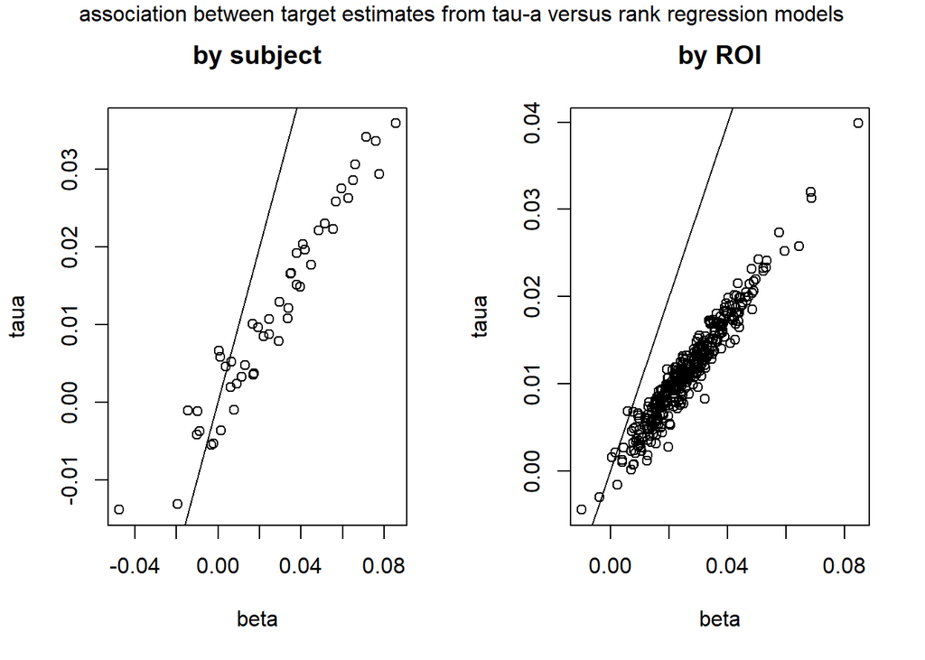

```
##           taua      beta
## taua 1.0000000 0.9712748
## beta 0.9712748 1.0000000
##           taua      beta
## taua 1.0000000 0.9653734
## beta 0.9653734 1.0000000
```

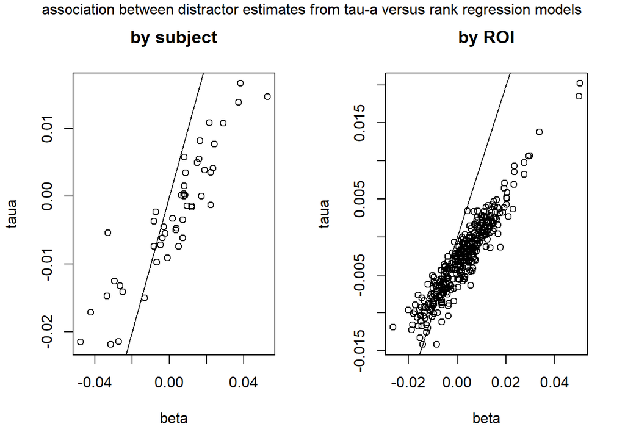

```
##           taua      beta
## taua 1.0000000 0.9121574
## beta 0.9121574 1.0000000
##          taua     beta
## taua 1.000000 0.938681
## beta 0.938681 1.000000
```

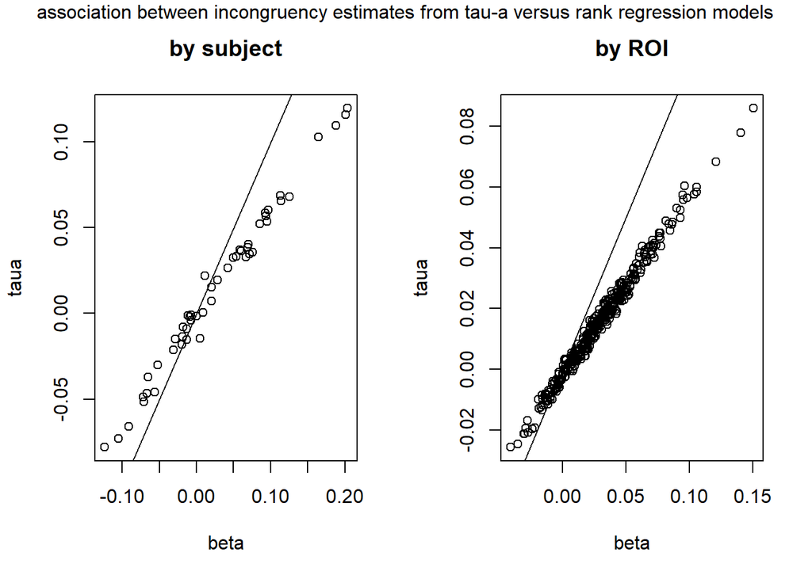

```
##           taua      beta
## taua 1.0000000 0.9933831
## beta 0.9933831 1.0000000
##           taua      beta
## taua 1.0000000 0.9929927
## beta 0.9929927 1.0000000
```

```r
## plot

plot.new()

for (ii in seq_along(params)) {

  # plot.new()
  par(mfrow = c(1, 2))

  d.tdic.taua %>%
    filter(param == params[ii]) %>%
    group_by(subj) %>%
    summarize_if(is.numeric, function(x) tanh(mean(atanh(x)))) %>%
    select(beta, taua) %>%
    plot
  abline(0, 1)
  title("by subject")

  d.tdic.taua %>%
    filter(param == params[ii]) %>%
    group_by(roi.hemi) %>%
    summarize_if(is.numeric, function(x) tanh(mean(atanh(x)))) %>%
    select(beta, taua) %>%
    plot
  abline(0, 1)
  title("by ROI")

  mtext(
    paste0("association between ", params[ii], " estimates from tau-a versus rank regression models"),
    side = 3, line = -1, outer = TRUE
    )

  d.tdic.taua %>%
    filter(param == params[ii]) %>%
    group_by(subj) %>%
    summarize_if(is.numeric, function(x) tanh(mean(atanh(x)))) %>%
    select(taua, beta) %>%
    cor %>%
    print

  d.tdic.taua %>%
    filter(param == params[ii]) %>%
    group_by(roi.hemi) %>%
    summarize_if(is.numeric, function(x) tanh(mean(atanh(x)))) %>%
    select(taua, beta) %>%
    cor %>%
    print

}
```

#### **preference analysis**: pairwise comparisons

```r
rank.vs.taua.intersect
```

```
## $target
##   [1] "1_l"      "1_r"      "10d_l"    "10pp_l"   "10r_r"    "10v_l"
##   [7] "10v_r"    "11l_l"    "11l_r"    "2_l"      "23c_l"    "23c_r"
##  [13] "24dd_l"   "24dd_r"   "24dv_l"   "24dv_r"   "31pv_r"   "3a_l"
##  [19] "3a_r"     "3b_l"     "3b_r"     "4_l"      "4_r"      "43_l"
##  [25] "43_r"     "44_l"     "44_r"     "45_l"     "46_l"     "47l_l"
##  [31] "47m_r"    "47s_l"    "55b_l"    "55b_r"    "5m_l"     "5mv_l"
##  [37] "5mv_r"    "6a_r"     "6d_l"     "6d_r"     "6ma_r"    "6mp_l"
##  [43] "6mp_r"    "6r_l"     "6r_r"     "6v_l"     "6v_r"     "7AL_r"
##  [49] "7PC_l"    "7PC_r"    "7PL_r"    "8Ad_l"    "8Ad_r"    "8Av_l"
##  [55] "8Av_r"    "8BL_r"    "8BM_l"    "8BM_r"    "8C_l"     "8C_r"
##  [61] "9-46d_r"  "9a_l"     "9a_r"     "9m_r"     "9p_l"     "a10p_l"
##  [67] "a10p_r"   "a24_l"    "a24_r"    "a24pr_l"  "a24pr_r"  "a32pr_r"
##  [73] "A4_l"     "A4_r"     "a47r_l"   "a47r_r"   "A5_l"     "A5_r"
##  [79] "a9-46v_r" "AAIC_r"   "AIP_l"    "AIP_r"    "AVI_l"    "AVI_r"
```

[output cut: 28 more lines]

```r
## target vs distractor

rois.taua.targt.vs.distr <- stats.pairs.taua %>%
  filter(
    roi.hemi %in% rank.vs.taua.intersect$target,
    p.targt.distr < 0.05,
    b.targt.distr > 0
    ) %>%
  .$roi.hemi

rois.tdic.targt.vs.distr <- stats.pairs.tdic %>%
  filter(
      roi.hemi %in% rank.vs.taua.intersect$target,
      p.targt.distr < 0.05,
      b.targt.distr > 0
    ) %>%
  .$roi.hemi

setdiff(rois.taua.targt.vs.distr, rois.tdic.targt.vs.distr)
```

```
## [1] "6ma_r"  "LO3_r"  "PFop_r" "V6_r"
```

```r
setdiff(rois.tdic.targt.vs.distr, rois.taua.targt.vs.distr)
```

```
## [1] "AVI_l"  "POS1_r"
```

```r
## target vs incongruency

rois.taua.targt.vs.incon <- stats.pairs.taua %>%
  filter(
    roi.hemi %in% rank.vs.taua.intersect$target,
    p.targt.incon < 0.05,
    b.targt.incon > 0,
    ) %>%
  .$roi.hemi

rois.tdic.targt.vs.incon <- stats.pairs.tdic %>%
  filter(
      roi.hemi %in% rank.vs.taua.intersect$target,
      p.targt.incon < 0.05,
      b.targt.incon > 0,
    ) %>%
  .$roi.hemi

setdiff(rois.taua.targt.vs.incon, rois.tdic.targt.vs.incon)
```

```
## character(0)
```

```r
setdiff(rois.tdic.targt.vs.incon, rois.taua.targt.vs.incon)
```

```
## [1] "11l_r"  "STGa_l"
```

## conclusions

$\tau_A$ models have expectedly worse (lower) fits than the rank regression models. This is expected because the $\tau_A$ are *bivariate* correlations, and the variables are negatively correlated. Thus, this comparison, as implemented here, is unfair.

A more appropriate comparison shold be performed by first orthogonalizing the variables, then computing $\tau_A$. TODO!